# Student Performance Prediction – Final Integrated Notebook

## Evaluate Tuned Models on Test Sets

Since further investigation is needed to pinpoint the exact reasons behind the similar performance of both datasets, I'll expect about the same results on the test sets as on the validation sets.

```
=== Random Forest (Original) on Test Set ===
Accuracy : 0.7558
Precision: 0.6973
Recall   : 0.6710
F1-score : 0.6792

Classification report:
              precision    recall  f1-score   support

     Dropout       0.79      0.72      0.75       853
    Enrolled       0.51      0.38      0.43       476
    Graduate       0.80      0.91      0.85      1325

    accuracy                           0.76      2654
   macro avg       0.70      0.67      0.68      2654
weighted avg       0.74      0.76      0.74      2654
```

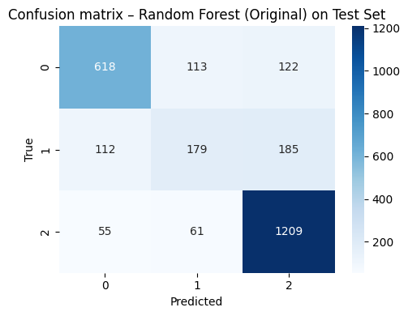

```
=== Random Forest (Processed) on Test Set ===
Accuracy : 0.7524
Precision: 0.6943
Recall   : 0.6803
F1-score : 0.6859

Classification report:
              precision    recall  f1-score   support

     Dropout       0.81      0.74      0.77       853
    Enrolled       0.47      0.42      0.44       476
    Graduate       0.81      0.88      0.84      1325

    accuracy                           0.75      2654
   macro avg       0.69      0.68      0.69      2654
weighted avg       0.75      0.75      0.75      2654
```

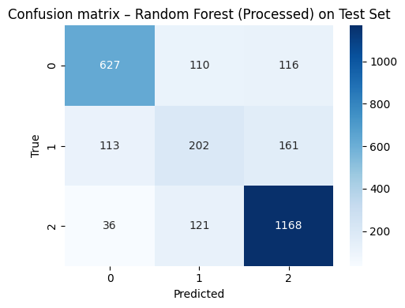

```
array(['Graduate', 'Graduate', 'Graduate', ..., 'Graduate', 'Dropout',
       'Graduate'], shape=(2654,), dtype=object)
```

```python
best_model_org = rf_clf_org_gs.best_estimator_
best_model_proc = rf_clf_proc_gs.best_estimator_

evaluate_model(best_model_org, X_test_org, y_test_org, title="Random Forest (Original) on Test Set")
evaluate_model(best_model_proc, X_test_proc, y_test_proc, title="Random Forest (Processed) on Test Set")
```

## Threshold optimization for the best classifier

We'll try to optimize the decision threshold for the best performing Random Forest classifier from the original dataset to achieve perfect precision while maximizing recall.  
Here we'll try to enforce binary classification by grouping the two lowest classes together (Dropout and Enrolled) and treating the highest class (Graduate) as the positive class.

```python
POSITIVE_CLASS = "Graduate"

y_train_org_bin = (y_train_org == POSITIVE_CLASS).astype(int)
y_val_org_bin = (y_val_org == POSITIVE_CLASS).astype(int)
y_test_org_bin = (y_test_org == POSITIVE_CLASS).astype(int)

y_train_proc_bin = (y_train_proc == POSITIVE_CLASS).astype(int)
y_val_proc_bin = (y_val_proc == POSITIVE_CLASS).astype(int)
y_test_proc_bin = (y_test_proc == POSITIVE_CLASS).astype(int)

best_model_org_bin = best_model_org
best_model_proc_bin = best_model_proc

best_model_org_bin.fit(X_train_org, y_train_org_bin)
```

```
Pipeline(steps=[('preprocess',
                 ColumnTransformer(transformers=[('num',
                                                  Pipeline(steps=[('scaler',
                                                                   StandardScaler())]),
                                                  ['Marital status',
                                                   'Application mode',
                                                   'Application order',
                                                   'Course',
                                                   'Daytime/evening attendance',
                                                   'Previous qualification',
                                                   'Previous qualification '
                                                   '(grade)',
                                                   'Nacionality',
                                                   "Mother's qualification",
                                                   "Father's qualification",
                                                   "Mother's occupation",
                                                   "Fat...
                                                   '(without evaluations)',
                                                   'Curricular units 2nd sem '
                                                   '(credited)',
                                                   'Curricular units 2nd sem '
                                                   '(enrolled)',
                                                   'Curricular units 2nd sem '
                                                   '(evaluations)', ...]),
                                                 ('cat',
                                                  Pipeline(steps=[('onehot',
                                                                   OneHotEncoder(handle_unknown='ignore'))]),
                                                  [])])),
                ('clf',
                 RandomForestClassifier(class_weight='balanced', max_depth=10,
                                        min_samples_leaf=2, n_estimators=300,
                                        n_jobs=-1, random_state=42))])
```

```python
best_model_proc_bin.fit(X_train_proc, y_train_proc_bin)
```

```
Pipeline(steps=[('preprocess',
                 ColumnTransformer(transformers=[('num',
                                                  Pipeline(steps=[('scaler',
                                                                   StandardScaler())]),
                                                  ['Application mode', 'Course',
                                                   'Previous qualification',
                                                   'Previous qualification '
                                                   '(grade)',
                                                   'Nacionality',
                                                   "Mother's qualification",
                                                   "Father's qualification",
                                                   'Admission grade',
                                                   'Age at enrollment',
                                                   'Curricular units 1st sem '
                                                   '(without evaluations)',
                                                   'Curric...
                                                   'Combined parental '
                                                   'occupation']),
                                                 ('cat',
                                                  Pipeline(steps=[('onehot',
                                                                   OneHotEncoder(handle_unknown='ignore'))]),
                                                  ['Application order',
                                                   'Displaced', 'Debtor',
                                                   'Tuition fees up to date',
                                                   'Gender',
                                                   'Scholarship holder'])])),
                ('clf',
                 RandomForestClassifier(class_weight='balanced', max_depth=10,
                                        min_samples_leaf=2, min_samples_split=5,
                                        n_estimators=300, n_jobs=-1,
                                        random_state=42))])
```

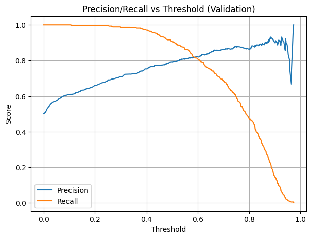

```python
y_scores_val_org = best_model_org_bin.predict_proba(X_val_org)[:, 1]

precisions_org, recalls_org, thresholds_org = precision_recall_curve(y_val_org_bin, y_scores_val_org)

plt.figure(figsize=(7,5))
plt.plot(thresholds_org, precisions_org[:-1], label="Precision")
plt.plot(thresholds_org, recalls_org[:-1],    label="Recall")
plt.xlabel("Threshold")
plt.ylabel("Score")
plt.title("Precision/Recall vs Threshold (Validation)")
plt.legend()
plt.grid(True)
plt.show()
```

```python
# Find indices where precision is 1.0 (no false positives on validation set)
perfect_prec_idx = np.where(precisions_org == 1.0)[0]

if len(perfect_prec_idx) == 0:
    print("No threshold gives perfect precision on validation set.")
else:
    # among these, choose the one with max recall
    best_idx = perfect_prec_idx[np.argmax(recalls_org[perfect_prec_idx])]
    best_threshold = thresholds_org[best_idx - 1]  # thresholds is one shorter than precisions/recalls

    print(f"Best threshold with perfect precision: {best_threshold:.4f}")
    print(f"Precision: {precisions_org[best_idx]:.4f}, Recall: {recalls_org[best_idx]:.4f}")
```

```
Best threshold with perfect precision: 0.9632
Precision: 1.0000, Recall: 0.0045
```

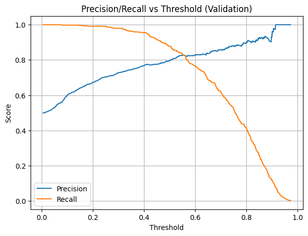

```python
y_scores_val_proc = best_model_proc_bin.predict_proba(X_val_proc)[:, 1]

precisions_proc, recalls_proc, thresholds_proc = precision_recall_curve(y_val_proc_bin, y_scores_val_proc)

plt.figure(figsize=(7,5))
plt.plot(thresholds_proc, precisions_proc[:-1], label="Precision")
plt.plot(thresholds_proc, recalls_proc[:-1],    label="Recall")
plt.xlabel("Threshold")
plt.ylabel("Score")
plt.title("Precision/Recall vs Threshold (Validation)")
plt.legend()
plt.grid(True)
plt.show()
```

```python
# Find indices where precision is 1.0 (no false positives on validation set)
perfect_prec_idx = np.where(precisions_proc == 1.0)[0]

if len(perfect_prec_idx) == 0:
    print("No threshold gives perfect precision on validation set.")
else:
    # among these, choose the one with max recall
    best_idx = perfect_prec_idx[np.argmax(recalls_proc[perfect_prec_idx])]
    best_threshold = thresholds_proc[best_idx - 1]  # thresholds is one shorter than precisions/recalls

    print(f"Best threshold with perfect precision: {best_threshold:.4f}")
    print(f"Precision: {precisions_proc[best_idx]:.4f}, Recall: {recalls_proc[best_idx]:.4f}")
```

```
Best threshold with perfect precision: 0.9128
Precision: 1.0000, Recall: 0.0792
```

### Evaluate threshold on test set

Finally, we'll evaluate the optimized threshold on the test set to see how well it performs in terms of accuracy, precision, recall, and F1-score.

```
=== Test performance with tuned threshold ===
Accuracy : 0.5535
Precision: 0.9545
Recall   : 0.1109
F1-score : 0.1988
```

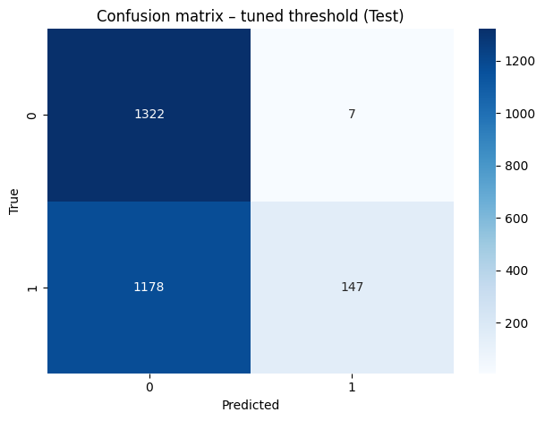

```python
# Apply the chosen threshold on the test set
y_scores_test = best_model_org_bin.predict_proba(X_test_org)[:, 1]
y_pred_test_thresh = (y_scores_test >= best_threshold).astype(int)

acc = accuracy_score(y_test_org_bin, y_pred_test_thresh)
prec = precision_score(y_test_org_bin, y_pred_test_thresh, zero_division=0)
rec  = recall_score(y_test_org_bin, y_pred_test_thresh, zero_division=0)
f1   = f1_score(y_test_org_bin, y_pred_test_thresh, zero_division=0)

print("=== Test performance with tuned threshold ===")
print(f"Accuracy : {acc:.4f}")
print(f"Precision: {prec:.4f}")
print(f"Recall   : {rec:.4f}")
print(f"F1-score : {f1:.4f}")

cm = confusion_matrix(y_test_org_bin, y_pred_test_thresh)
sns.heatmap(cm, annot=True, fmt="d", cmap="Blues")
plt.title("Confusion matrix – tuned threshold (Test)")
plt.xlabel("Predicted")
plt.ylabel("True")
plt.tight_layout()
plt.show()
```

```
=== Test performance with tuned threshold ===
Accuracy : 0.5460
Precision: 0.9478
Recall   : 0.0958
F1-score : 0.1741
```

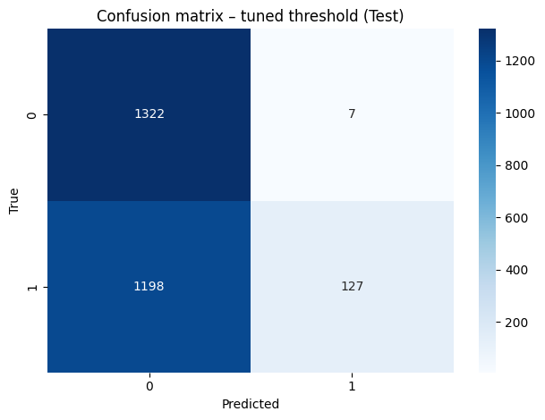

```python
# Apply the chosen threshold on the test set
y_scores_test = best_model_proc_bin.predict_proba(X_test_proc)[:, 1]
y_pred_test_thresh = (y_scores_test >= best_threshold).astype(int)

acc = accuracy_score(y_test_proc_bin, y_pred_test_thresh)
prec = precision_score(y_test_proc_bin, y_pred_test_thresh, zero_division=0)
rec  = recall_score(y_test_proc_bin, y_pred_test_thresh, zero_division=0)
f1   = f1_score(y_test_proc_bin, y_pred_test_thresh, zero_division=0)

print("=== Test performance with tuned threshold ===")
print(f"Accuracy : {acc:.4f}")
print(f"Precision: {prec:.4f}")
print(f"Recall   : {rec:.4f}")
print(f"F1-score : {f1:.4f}")

cm = confusion_matrix(y_test_proc_bin, y_pred_test_thresh)
sns.heatmap(cm, annot=True, fmt="d", cmap="Blues")
plt.title("Confusion matrix – tuned threshold (Test)")
plt.xlabel("Predicted")
plt.ylabel("True")
plt.tight_layout()
plt.show()
```

## Regrettable Notice

I would love to do further investigations and improvements on this notebook, but due to time constraints and other obligations, I regret to inform that I will not be able to continue working on this assignment.  
To be more spesific , I would have liked to:

- Explore additional models such as XGBoost or ensemble methods.
- Revisit feature engineering and selection to identify additional relevant features.
- Implement evaluation techniques which is listed in the `workshop0511.ipynb`.

These are points I'll definitely return to when time would deem it possible.

## Appendix: Full Manual ANN Code

# Mandatory: Artificial Neural Networks

## Building a ANN from Scratch in Python

In this tutorial, we will build a simple Artificial Neural Network (ANN) from scratch using Python.  
The purpose for this exersize is to aquire a deeper understanding of how ANNs are structured, before implementing the same consepts with ANN libraries like `TensorFlow` an `PyTorch`.

The work preformed in this notebook is inspired from the article "[Building Artificial Neural Networks (ANN) from Scratch](https://www.geeksforgeeks.org/deep-learning/building-artificial-neural-networks-ann-from-scratch/)", which is an instructional article on how to build a functioning ANN machine without pre-defined libraries.

To further understand the content of the article and its content, I've used `Chat GPT`([ANN conversation](https://chatgpt.com/share/6920acb1-0e78-800e-beb9-10212bd96007), [numpy explanations](https://chatgpt.com/share/6920ae0f-4b18-800e-bb3c-3b497c7a267d)) as a companion assistant to explain how the code is tied togheter and how certain mathematical function in the `numpy` library works.

### Package Import

As mentioned above this notebook contains a minimum of packages to make the solution functional.  
The imported libraries are only intended to solve or simplify longer prosesses like mathematical calculation, import of data and partitioning of data into train and test partiotions.

**Packages:**

- numpy - Used to simplify mathematical challenges which would be quite demaninding to do manually.
- pandas - Used for import of data and simple data manipulations, like one-hot encoding etc.

```python
import numpy as np
import matplotlib.pyplot as plt
import pandas as pd
import seaborn as sns

from sklearn.model_selection import train_test_split
from sklearn.preprocessing import StandardScaler
from sklearn.metrics import classification_report, confusion_matrix
```

### Functions

Since we're not going to relay on pre-defined libraries for this exersize, it's necessary to create our own library to compensate for this. The following cells contains different functions which will be used to build a final training function for the ANN machine.

Cells below consists of following topics:

- Train, Validation and Test Split.
- Initial Parameters.
- Activation Functions.
- Forward Propagation.
- Computing Cost.
- Backpropagation.
- Updating Parameter.
- Model Training.
- Making Predictions.

#### Train, Test and Split.

Here we use a pre-written function which has been used in earlier assigments.  
This functions let's us effectivly divide provided data into `train`, `validation` and `test` partitions.

I've added a small change to the function this round, so if no size is defined for the validation (default), then it will only return `train` and `test` partitions for the dataset.

By default the random seed is set to `None` which makes the split random at each run. For instances where reproducibility is important, this value should be defined with a numeric value.

Stratification is oriented around a single target column, so this function will work properly on datasets that consists of binary/multiclass classifications, but not on multilabel classifications with more than one target column.

```python
def stvts(df, target_col, test_size=0.2, val_size=0.0, random_state=None):
    # 1. Split into train+val and test
    train_val, test = train_test_split(
        df,
        test_size=test_size,
        stratify=df[target_col],
        random_state=random_state
    )
    if val_size > 0:
        # 2. Split train+val into train and validation
        relative_val_size = val_size / (1 - test_size)
        train, val = train_test_split(
            train_val,
            test_size=relative_val_size,
            stratify=train_val[target_col],
            random_state=random_state
        )
        # 3. Verify stratification
        print("Training set class distribution:")
        print(train[target_col].value_counts()/train.shape[0])
        print("Validation set class distribution:")
        print(val[target_col].value_counts()/val.shape[0])
        print("Test set class distribution:")
        print(test[target_col].value_counts()/test.shape[0],"\n")

        # 4. Separate features (X) and labels (y)
        X_train, y_train = train.drop(columns=[target_col]), train[target_col]
        X_val, y_val     = val.drop(columns=[target_col]), val[target_col]
        X_test, y_test   = test.drop(columns=[target_col]), test[target_col]

        # 5. print shapes of the splits
        print(f"Train set shape:\n {X_train.shape}, {y_train.shape}")
        print(f"Validation set shape:\n {X_val.shape}, {y_val.shape}")
        print(f"Test set shape:\n {X_test.shape}, {y_test.shape}")

        # 6. return the splits
        return X_train, X_val, X_test, y_train, y_val, y_test
    else:
        # 2. Remove Validation
        train = train_val

        # 3. Verify stratification
        print("Training set class distribution:")
        print(train[target_col].value_counts()/train.shape[0])
        print("Test set class distribution:")
        print(test[target_col].value_counts()/test.shape[0],"\n")

        # 4. Separate features (X) and labels (y)
        X_train, y_train = train.drop(columns=[target_col]), train[target_col]
        X_test, y_test   = test.drop(columns=[target_col]), test[target_col]

        # 5. print shapes of the splits
        print(f"Train set shape:\n {X_train.shape}, {y_train.shape}")
        print(f"Test set shape:\n {X_test.shape}, {y_test.shape}")

        # 6. return the splits
        return X_train, X_test, y_train, y_test
```

#### Initial Parameters.

This cell contains a function for the initial parameters for the model.  
These are the parameters which a model use as a base for training the model on the given dataset.  
The randomization for initialization has been set to a static seed values. This is to ensure that each run start with the same random seed to ensure reproducibility on the machine training stage.

The function creates a dictionary that contains the following:

- Weights (`W1`, `W2`) -- Initialized with small random values scaled by $0.01$ to prevent large initial weights. The initial weight values will be defined based on the number of neuron assigned to the input, hidden and output layer in the neural network, which defines the shape of each weight.
- Biases (`b1`, `b2`) -- Initialized to zero vectors matching their layer sizes.

```python
def initialize_parameters(input_size, hidden_size, output_size):
    np.random.seed(42)  # For reproducibility
    parameters = {
        "W1": np.random.randn(hidden_size, input_size) * 0.01,
        "b1": np.zeros((hidden_size, 1)),
        "W2": np.random.randn(output_size, hidden_size) * 0.01,
        "b2": np.zeros((output_size, 1))
    }
    return parameters
```

#### Activation Functions.

[Activation functions](https://www.geeksforgeeks.org/machine-learning/activation-functions-neural-networks/) are mathematical functions that's beeing applied to the output of a neuron.  
It's these functions that work as decision makers for the training process.  
For each run during training activation functions decide whether a neuron should be activated based on the weighted sum of inputs and a bias term.  
They also make backpropagation possible by providing gradients for weight updates.  
With these functions we're able to introduce non-linearity, which enables the model to learn and represent complex data patterns.

**Hidden Layer**  
Here we'll use [ReLU](https://www.geeksforgeeks.org/deep-learning/relu-activation-function-in-deep-learning/) since this is considered to be the best all-around function because of its simplicity and effectiveness.  
Mathematically `ReLU` is defined as: $f(x)=max(0,x)$.  
This function allows positive values to pass through unchanged while negative values are being set to $0$(zero).  
With this we'll help the neural network maintain complexity to learn patterns and avoid typical pittfalls like the [vanishing gradient problem](https://www.geeksforgeeks.org/deep-learning/vanishing-and-exploding-gradients-problems-in-deep-learning/).

**Output Layer**  
Since we're dealing with multiclass targeted data for this assigment we'll use the [Softmax Function](https://www.geeksforgeeks.org/deep-learning/the-role-of-softmax-in-neural-networks-detailed-explanation-and-applications/) for the output layer.  
`Softmax` transforms a vector of numbers into a probability distribution, where each value represents the likelihood of a particular class. It is especially important for multi-class classification problems.  
This function gives each output a values between $0$ and $1$, where the sum of all output values equals to $1$. Mathematically `Softmax` is defined as: $\sigma(Z_i)=\frac{e^{z_i}}{\sum_{j=1}^n e^{z_j}}$.

- $e^{z_j}$: Exponentiation of the input value.
- $\sum_{j=1}^n e^{z_j}$: Sum of all exponentiated values to normalize outputs.

**Backpropagation**  
For backpropagation we'll use the derivative of `ReLU`. This done to achieve correct computation of gradients for each train loop.  
In practice this is used to apply the chain rule during backprop to determine which neurons that's getting updated to prevent incorrect updates.  
This is considered as a crutial part for training `ReLU`-based networks like the one we're building here.  
Mathematically `ReLU'` can be defined as: $ReLU'(z)=\begin{cases} 1\ if\ z>0\\0\ if\ z\le 0\end{cases}$

```python
def relu(Z):
    return np.maximum(0, Z)

def softmax(Z):
    Z_shift = Z - np.max(Z, axis=0, keepdims=True)   # stability trick
    exp_values = np.exp(Z_shift)
    probabilities = exp_values / np.sum(exp_values, axis=0, keepdims=True)
    return probabilities

def relu_derivative(Z):
    return (Z > 0).astype(int)
```

#### Forward Propagation.

[Forward propagation](https://www.geeksforgeeks.org/deep-learning/what-is-forward-propagation-in-neural-networks/) computes the output of the neural network for a given input X and parameters, with the following steps:

1. Calculate the linear combinations `Z1` for the hidden layer by multiplying the input X with the weights `W1` and adding bias `b1`.
2. Applies the `ReLU` activation function to `Z1` thus producing the hidden layer activations `A1`.
3. Calculate the linear combinations `Z2` for the output layer by multiplying `A1` with `W2` and adding bias `b2`.
4. `Softmax` activation function is applied to `Z2` to produce the final output `A2`.
5. Returns the output `A2` along with a `cache` dictionary containing intermediate values for backpropagation.

```python
def forward_propagation(X, parameters):
    W1, b1, W2, b2 = parameters["W1"], parameters["b1"], parameters["W2"], parameters["b2"]

    Z1 = np.dot(W1, X) + b1
    A1 = relu(Z1)
    Z2 = np.dot(W2, A1) + b2
    A2 = softmax(Z2)

    cache = {"Z1": Z1, "A1": A1, "Z2": Z2, "A2": A2}
    return A2, cache
```

#### Computing Cost.

- m is the number of examples.
- np.squeeze removes any extra dimensions, returning the cost as a scalar.

```python
def compute_cost(Y, A2):
    m = Y.shape[1]
    cost = -np.sum(Y * np.log(A2 + 1e-12)) / m
    return np.squeeze(cost)
```

#### Backpropagation.

[Backpropagation](https://www.geeksforgeeks.org/machine-learning/backpropagation-in-neural-network/) computes the gradients needed to update the network parameters during training.

- It calculates the error at the output layer `dZ2` as the difference between predicted outputs `A2` and true labels `Y`.
- Using this error, it computes gradients of the weights `dW2` and biases `db2` for the output layer.
- Then, it backpropagates the error to the hidden layer by multiplying with the transpose of `W2` and element-wise with the derivative of the `ReLU` activation (`ReLU'`).
- Finally, it calculates gradients for the hidden layer weights `dW1` and biases `db1`.
- All gradients are averaged over the number of examples `m` to ensure stable updates.

```python
def backward_propagation(X, Y, parameters, cache):
    m = X.shape[1]
    W2 = parameters["W2"]

    dZ2 = cache["A2"] - Y
    dW2 = np.dot(dZ2, cache["A1"].T) / m
    db2 = np.sum(dZ2, axis=1, keepdims=True) / m

    dZ1 = np.dot(W2.T, dZ2) * relu_derivative(cache["Z1"])
    dW1 = np.dot(dZ1, X.T) / m
    db1 = np.sum(dZ1, axis=1, keepdims=True) / m

    grads = {"dW1": dW1, "db1": db1, "dW2": dW2, "db2": db2}
    return grads
```

#### Updating Parameter.

[Gradient descent](https://www.geeksforgeeks.org/machine-learning/gradient-descent-algorithm-and-its-variants/) updates the parameters using the computed gradients and a learning rate.

This function combined with **backpropagation** is considered the backbone of several learning algorithms, included ANNs.  
It serves as a optimization technique to minimize the cost function by iteratively adjusting the model parameters to reduce the difference between predicted and actual values, improving the model's performance.

Since we store the parameters in a dictionary we can easily call iteratively on the with the `keys()` function and apply new values to the weights and biases.

Flow of the function:

> `Parameters inn`  
> ↓  
> subtract `learning_rate` multiply with `gradients`  
> ↓  
> `New parameters out`

```python
def update_parameters(parameters, grads, learning_rate):
    for key in parameters.keys():
        parameters[key] -= learning_rate * grads["d" + key]
    return parameters
```

#### Model Training.

We train the neural network over multiple iterations, updating parameters using backpropagation and gradient descent.

- Firstly we'll start by defining a starting point with the initial parameters.
- Then we'll start the iterative training of the model.
- For each iteration we'll store the compute cost results, since these can potentially be used to evaluate if the model is learning properly later.
- The function prints the iteration sequence (epoch) and compute cost for each 100'th iteration.
- When the iteration is completed the final tuning parameters are returned ready to be fitted and tested on the target data.

The function takes the following arguments:

| Argument | Description |
| --- | --- |
| `X` | Features. |
| `Y` | Targets. |
| `input_size` | Number of neurons for the input layer. |
| `hidden_size` | Number of neurons for the hidden layer. |
| `output_layer` | Number of neurons for the output layer. |
| `epochs` | Number of iterations in the training sequence (default = $1000$). |
| `learning_rate` | Hyperparameter influencing the size of steps taken during the optimization process to update the model parameters (default = $0.01$). |

```python
def train_neural_network(X, Y, input_size, hidden_size, output_size, epochs=1000, learning_rate=0.01):
    parameters = initialize_parameters(input_size, hidden_size, output_size)
    costs = []

    for i in range(epochs):
        A2, cache = forward_propagation(X, parameters)
        cost = compute_cost(Y, A2)
        costs.append(cost)
        grads = backward_propagation(X, Y, parameters, cache)
        parameters = update_parameters(parameters, grads, learning_rate)

        if i % 100 == 0:
            print(f"Epoch {i}: Cost = {cost}")

    plt.plot(costs)
    plt.xlabel("Epoch")
    plt.ylabel("Cost")
    plt.title("Training Loss Curve")
    plt.show()
    return parameters
```

#### Making Predictions.

Since we're using `softmax` to calculate the output layer, we'll use `argmax` from `numpy` to get the right predictions for a multiclass classifier.

We do this because `softmax` produces a probability distribution accross all classes. This way we'll allways choose the class with the highest `softmax` probability.

This will return an index corresponding to the predicted classes.

```python
def predict(X, parameters):
    A2, _ = forward_propagation(X, parameters)
    return np.argmax(A2, axis=0)
```

### Testing the Model

Now that the model has been build we can finally start training and testing the model.

In this section we'll:

- Import the data.
- Split data into test and train partitions.  
  In this case we'll divide the set into 70/30 partitions.  
  This will give us about $3000$ rows for training and about $1300$ rows for testing predictions.
- Train the model on test data.  
  Since we have a target, this will be a supervised training of the model where we'll be training the model with classes and their corresponding targets.
- Test predictions on unseen test data with the tuned parameters from the previous training.
- Evaluate the model performance with accuracy, confusion matrix and classification report.
- Make adjustemts based on the findings from previous step.
- Retrain and retest the model until satisfied with the results.

#### Data import

We'll base this on the same data which was used during the third mandatory assigment for `student_predictions`.  
The training and testing will be preformed only on the original dataset provided for this assigment.

```python
student_original_df = pd.read_csv('../data/student_predictions.csv', sep=';')
```

#### Split into train/test

##### Split Train Test Startify Original Dataset

```python
X_train, X_test, y_train, y_test = stvts(student_original_df, "Target", 0.3)
```

```
Training set class distribution:
Target
Graduate    0.499354
Dropout     0.321059
Enrolled    0.179587
Name: count, dtype: float64
Test set class distribution:
Target
Graduate    0.499247
Dropout     0.321536
Enrolled    0.179217
Name: count, dtype: float64

Train set shape:
 (3096, 36), (3096,)
Test set shape:
 (1328, 36), (1328,)
```

##### Split Evaluation

I've added some print to the `stvts` functions that gives us some shallow insight to the sets we'll be training our model on.  
From the output above, we can see that the stratifying of classes works as intended since the target distributions is almost even between train and test data.  
We observe that the shape of the dataset also corresponds with expected outcome.

One thing that might cause issues when traing our data on this set it the internal distribution of targets.  
Out of three possible predictions, the `Graduate` class consists of almost $50\%$ of the rows in the data. This might create an issue with the model always predicting `Graduate`, since this will ensure about $50\%$ accuracy. This suggests that there might be a need to **normalize** our input features to improve the results.  
We'll first look at a base run on the original data before we eventually start preprocessing our datasets.

#### Train Base Model

At the first attempt of trying to train this modell, there where some challenges that needed to be adressed for this solution to work as intended.

1. **Build class mapping from labels.**  
   Firstly it turned out that this model is not able to takes string values, which is what the target values are. To solve this I had to create a numeric index of the targets. This was solved by creating a list consisting of the possible target values.  
   The list is sorted for reproducibility reasons.  
   Finally a `Class mapping` is being printed to illustrate which numeric value a target has been assigned. This list was then used to build a mapping dictionary that assigns a numeric value to each target.
2. **Convert string labels to integer indices.**  
   With the numeric target dictionary it's now possible to assign numeric values to the targets in the dataset with the following logic:

| Code | Description |
| --- | --- |
| `y_train.map(class_to_int)` | Converts each string label into the corresponding numeric ID based on the `Class mapping` dictionary. |
| `.astype(int)` | Here we enforce dtype to int values to avoid unintentional numerics being interpeted as string values. |
| `.values` | Converts the pandas Series into a raw NumPy array. |
| `.reshape(-1)` | Here we ensure the shape of the array. This is needed to make further one-hot encoding possible. |

3. **One-hot encode.**  
   This step gives a **indexed identity matrix** where each sample becomes a one-hot vector.

Description

`num_classes = len(class_to_int)`

Start by getting a count of the classes. This makes it possible to create a **identity matrix** for one-hot encoding of the target classes.

`np.eye(num_classes)[y_train_int].T`

- Takes the class count and create a **identity matrix** based on the number of classes.
- The numeric class values is then being used to index rows of the matrix.
- Final result of the matrix is then transposed to accommodate the expected shape from our **ANN** setup.
4. **Transpose X for the neural network.**  
   Because of a logical error in the **ANN** build this solution expect the shape of data to be `(n_features, n_samples)`, but the output we get from pandas is currently `(n_samples, n_features)`.  
   This is solved by transposing the shape of the data to match the expected shape.
5. **Train neural network.**  
   Here we pre-define the number of neurons for the different layers in the Neural Network.
   - The input and output layer is defined by the content in the dataset, and will change according to the content of data used for training.
   - The hidden layer is the only layer which is defined with a static value that can be changed to tune the model.  
     This is a very relavant step in regards of performance tuning for small manual ANNs.
     - Too **few** neurons might result in the model not being able to learn enough patterns, which leads to a underfitting issues on the model.  
       This might lead the model to not being able to capture:
       - Non-linear relationships.
       - Interactions between features.
       - Hierarchical structures.
     - Too **many** neurons could lead to overfitting the model and potentially result in unstable training sessions.  
       This might result in issues like:
       - Very low training loss, very poor test accuracy.
       - Training oscillates or spikes.
       - Softmax blows up → NaNs.
       - Model memorizes training data (overfitting).

   Based on this we'll start the base run with $50$ neurons in `HL` and evaluate if this is a good number for a stable run resulting in a gradient loss of cost throughout the training session.

```
Class mapping: {'Dropout': 0, 'Enrolled': 1, 'Graduate': 2}
Epoch 0: Cost = 1.2914222591602567
Epoch 100: Cost = 1.0613273383803454
Epoch 200: Cost = 1.0412644343878898
Epoch 300: Cost = 1.0313286004548452
Epoch 400: Cost = 1.0258787620623409
Epoch 500: Cost = 1.0226710233044058
Epoch 600: Cost = 1.0206236279052299
Epoch 700: Cost = 1.0192034407281263
Epoch 800: Cost = 1.0181246505249406
Epoch 900: Cost = 1.017244031418629
Epoch 1000: Cost = 1.0165168074737576
Epoch 1100: Cost = 1.0159229899689746
Epoch 1200: Cost = 1.0154451022946867
Epoch 1300: Cost = 1.015069151748354
Epoch 1400: Cost = 1.01477836969874
Epoch 1500: Cost = 1.0145456839646292
Epoch 1600: Cost = 1.0143546478121688
Epoch 1700: Cost = 1.0141920734811791
Epoch 1800: Cost = 1.0140412168710264
Epoch 1900: Cost = 1.0139120913412316
Epoch 2000: Cost = 1.0137931193767054
Epoch 2100: Cost = 1.013682817533496
Epoch 2200: Cost = 1.0135710189616067
Epoch 2300: Cost = 1.0134663634308783
Epoch 2400: Cost = 1.0133721506861078
Epoch 2500: Cost = 1.013272360973672
Epoch 2600: Cost = 1.013179178633355
Epoch 2700: Cost = 1.0136390140818206
Epoch 2800: Cost = 1.013407993892477
Epoch 2900: Cost = 1.0132482625456412
Epoch 3000: Cost = 1.0131211422645174
Epoch 3100: Cost = 1.0130127697255615
Epoch 3200: Cost = 1.0129154000574816
Epoch 3300: Cost = 1.0128235614490393
Epoch 3400: Cost = 1.0127362155107291
Epoch 3500: Cost = 1.0126467863334927
Epoch 3600: Cost = 1.0125639505830433
Epoch 3700: Cost = 1.0125028652238361
Epoch 3800: Cost = 1.0124083529758183
```

[output cut: 46 more lines]

```
Epoch 8500: Cost = 1.0074536111281165
Epoch 8600: Cost = 1.0073274360740792
Epoch 8700: Cost = 1.0072117807762146
Epoch 8800: Cost = 1.007102608787901
Epoch 8900: Cost = 1.0070021039291126
Epoch 9000: Cost = 1.0069015237922374
Epoch 9100: Cost = 1.0068109087514203
Epoch 9200: Cost = 1.0067255438346494
Epoch 9300: Cost = 1.0066404884575137
Epoch 9400: Cost = 1.0065709407496486
Epoch 9500: Cost = 1.0064897663595795
Epoch 9600: Cost = 1.0064199076957552
Epoch 9700: Cost = 1.006350663955356
Epoch 9800: Cost = 1.0062969181841097
Epoch 9900: Cost = 1.0084878398446664
```

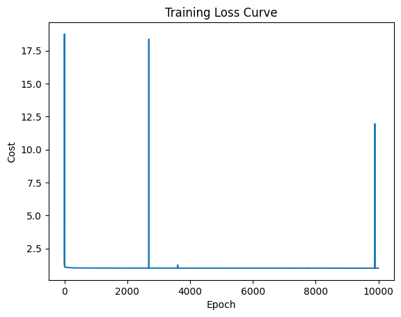

```python
# 1. Build class mapping from labels
classes = sorted(y_train.unique())
class_to_int = {c: i for i, c in enumerate(classes)}
print("Class mapping:", class_to_int)

# 2. Convert string labels to integer indices
y_train_int = y_train.map(class_to_int).astype(int).values.reshape(-1)

# 3. One-hot encode
num_classes = len(class_to_int)
Y_train = np.eye(num_classes)[y_train_int].T

# 4. Transpose X for the neural network
X_train = X_train.T

# 5. Train neural network
IL = X_train.shape[0]
HL = 50
OL = num_classes

trained_parameters = train_neural_network(X_train, Y_train, IL, HL, OL, 10000)
```

##### Base Train Evaluated on Cost

After running the base model on $10000$ iterations we can make some assumtions regarding the cost values.

  This indicates a rather poor learning curve after the first $100$ runs.  
  One possible explanation for this is the uneven distributions of target values, meaning that the model start favoring the `Graduate` class at an early stage.

##### Evaluate predictions on Base Model

Based on the cost loss evaluation we're not expecting the best results at this stage.  
The model is expected to favor `Graduate` in it's prediction and thereby to do a lot of faulty predictions on the two other classes.

To evaluate the predictions we'll be using `classification_report` and `confusion_matrix`.

- `classification_report`
  - Returns score values on the target classes precision, recall value and f1-score.
  - Returns an average score on accuracy, macro (averaging the unweighted mean per label) and weighted (averaging the support-weighted mean per label).
- `confusion_matrix`(with plot)
  - Gives a visual representation in the shape of a grid heatmap, that shows the distributions of predictions. With this we can more easily consider the validity of predictions.

```
              precision    recall  f1-score   support

     Dropout       0.57      0.04      0.07       427
    Enrolled       0.00      0.00      0.00       238
    Graduate       0.50      0.99      0.67       663

    accuracy                           0.50      1328
   macro avg       0.36      0.34      0.25      1328
weighted avg       0.44      0.50      0.36      1328
```

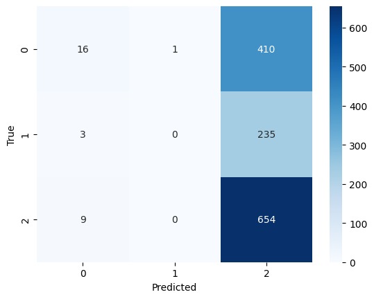

```python
y_test_int = y_test.map(class_to_int).astype(int).values.reshape(-1)
predictions = predict(X_test.T, trained_parameters)

print(classification_report(y_test_int, predictions, target_names=classes))

cm = confusion_matrix(y_test_int, predictions)

sns.heatmap(cm, annot=True, fmt="d", cmap="Blues")
plt.xlabel("Predicted")
plt.ylabel("True")
plt.show()
```

##### Considering the Results on Base Predictions

As expected we can conduct that this models favors the `Graduate` class far to much to give accurate predictions.  
Right now almost every row is being classified as `Graduate`, which in turn results in about $50\%$ accuracy becuase of imbalanced classification in the data.

#### Tuning

In this section we'll go through the process of trying to improve the precission on predictions.  
Here we'll do training over several steps where a tweak gets implemented for each stage.

##### Tuning Steps

The next steps where to tweak the parameters which was not beeing controlled inside the `HL` trough the activation functions.  
This gave three possible things to adjust the training process:

- Proportion split for train/test data.
- Number of neurons in `HL`.
- Number of runs in a training session(epochs).

```
Training set class distribution:
Target
Graduate    0.499354
Dropout     0.321059
Enrolled    0.179587
Name: count, dtype: float64
Test set class distribution:
Target
Graduate    0.499247
Dropout     0.321536
Enrolled    0.179217
Name: count, dtype: float64

Train set shape:
 (3096, 36), (3096,)
Test set shape:
 (1328, 36), (1328,)
Epoch 0: Cost = 1.0983133988499383
Epoch 100: Cost = 1.0562226407226987
Epoch 200: Cost = 1.029499236649983
Epoch 300: Cost = 1.0019955937972203
Epoch 400: Cost = 0.9582924456999657
Epoch 500: Cost = 0.8908347620908726
Epoch 600: Cost = 0.8192955144204735
Epoch 700: Cost = 0.765706563983897
Epoch 800: Cost = 0.7283823960550905
Epoch 900: Cost = 0.7009418282938142
Epoch 1000: Cost = 0.6800054998808666
Epoch 1100: Cost = 0.6639205991026539
Epoch 1200: Cost = 0.651264774143689
Epoch 1300: Cost = 0.6410538507754983
Epoch 1400: Cost = 0.6326926751416659
Epoch 1500: Cost = 0.6256818645737561
Epoch 1600: Cost = 0.619693331388769
Epoch 1700: Cost = 0.6144504084485428
Epoch 1800: Cost = 0.6098156460017491
Epoch 1900: Cost = 0.6056828774484899
Epoch 2000: Cost = 0.6019381667257224
Epoch 2100: Cost = 0.5985117387458858
Epoch 2200: Cost = 0.5953515254050331
```

[output cut: 62 more lines]

```
Epoch 8500: Cost = 0.5268511764887964
Epoch 8600: Cost = 0.5262255429416715
Epoch 8700: Cost = 0.5255889400569212
Epoch 8800: Cost = 0.5249450979904615
Epoch 8900: Cost = 0.5243086030161986
Epoch 9000: Cost = 0.5236783371642673
Epoch 9100: Cost = 0.5230456450203635
Epoch 9200: Cost = 0.5224076474674292
Epoch 9300: Cost = 0.5217691326773934
Epoch 9400: Cost = 0.5211322664073736
Epoch 9500: Cost = 0.5204940928148386
Epoch 9600: Cost = 0.5198555600208637
Epoch 9700: Cost = 0.5192154106660056
Epoch 9800: Cost = 0.5185797399435824
Epoch 9900: Cost = 0.5179508876492172
```

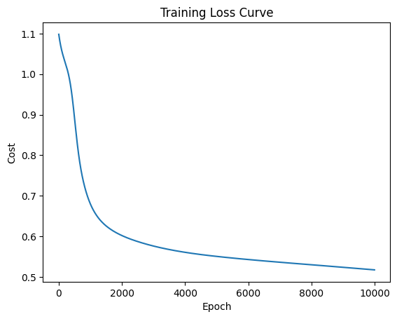

```python
scaler = StandardScaler()

student_original_df = pd.read_csv('../data/student_predictions.csv', sep=';')
X_train, X_test, y_train, y_test = stvts(student_original_df, "Target", 0.3)

# Build mapping
classes = sorted(y_train.unique())
class_to_int = {c: i for i, c in enumerate(classes)}

# Convert labels to integers
y_train_int = y_train.map(class_to_int).astype(int).values.reshape(-1)

# One-hot encode
num_classes = len(class_to_int)
Y_train = np.eye(num_classes)[y_train_int].T

X_train_scaled = scaler.fit_transform(X_train)
X_test_scaled = scaler.transform(X_test)

X_train = X_train_scaled.T
X_test = X_test_scaled.T

IL = X_train.shape[0]
HL = 80
OL = num_classes

trained_parameters = train_neural_network(X_train, Y_train, IL, HL, OL, 10000)
```

##### Tuning Results

Here are some of the plots for the **Training Loss Curve** that shows the different results from tuning the model:

[figure not shown]

```
              precision    recall  f1-score   support

     Dropout       0.85      0.75      0.80       427
    Enrolled       0.56      0.39      0.46       238
    Graduate       0.80      0.94      0.86       663

    accuracy                           0.78      1328
   macro avg       0.73      0.69      0.71      1328
weighted avg       0.77      0.78      0.77      1328
```

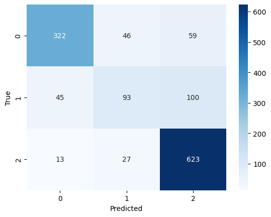

```python
y_test_int = y_test.map(class_to_int).astype(int).values.reshape(-1)
predictions = predict(X_test, trained_parameters)

print(classification_report(y_test_int, predictions, target_names=classes))

cm = confusion_matrix(y_test_int, predictions)

sns.heatmap(cm, annot=True, fmt="d", cmap="Blues")
plt.xlabel("Predicted")
plt.ylabel("True")
plt.show()
```

##### Test Run on pre-processed Data

From the last assignment we found that the processing steps we preformed on this dataset didn't yield in any improvments for the model training.  
I would still like to test the results on this model with the processed data.  
For this run we'll be using what we found to be the best tuning for the original dataset and see if there is any improvement on the processed data.  
To make the comparison fair this data will also be normalized before the training run.

```
Training set class distribution:
Target
Graduate    0.499354
Dropout     0.321059
Enrolled    0.179587
Name: count, dtype: float64
Test set class distribution:
Target
Graduate    0.499247
Dropout     0.321536
Enrolled    0.179217
Name: count, dtype: float64

Train set shape:
 (3096, 26), (3096,)
Test set shape:
 (1328, 26), (1328,)
Epoch 0: Cost = 1.0980954751422562
Epoch 100: Cost = 1.0574812113592524
Epoch 200: Cost = 1.0339651433363621
Epoch 300: Cost = 1.0153219132436382
Epoch 400: Cost = 0.991805133411403
Epoch 500: Cost = 0.9535588886463214
Epoch 600: Cost = 0.8954965450274123
Epoch 700: Cost = 0.8297745565152845
Epoch 800: Cost = 0.7761186582722509
Epoch 900: Cost = 0.7386139422098662
Epoch 1000: Cost = 0.7120649934047341
Epoch 1100: Cost = 0.6919534475866587
Epoch 1200: Cost = 0.6759824379009366
Epoch 1300: Cost = 0.6629400689900732
Epoch 1400: Cost = 0.6520725052079632
Epoch 1500: Cost = 0.642913993525401
Epoch 1600: Cost = 0.6351219576905331
Epoch 1700: Cost = 0.6284154092114183
Epoch 1800: Cost = 0.6225668633842862
Epoch 1900: Cost = 0.6173541987579946
Epoch 2000: Cost = 0.6127289682803989
Epoch 2100: Cost = 0.6085265875094638
Epoch 2200: Cost = 0.6047214517724546
```

[output cut: 62 more lines]

```
Epoch 8500: Cost = 0.5230898984119031
Epoch 8600: Cost = 0.5225500569480083
Epoch 8700: Cost = 0.5220090690705803
Epoch 8800: Cost = 0.521473292327371
Epoch 8900: Cost = 0.520943267823965
Epoch 9000: Cost = 0.5204095152553747
Epoch 9100: Cost = 0.519875892346611
Epoch 9200: Cost = 0.519344842343757
Epoch 9300: Cost = 0.5188178883104971
Epoch 9400: Cost = 0.5182972858463045
Epoch 9500: Cost = 0.5177800089616645
Epoch 9600: Cost = 0.5172716703011743
Epoch 9700: Cost = 0.5167695900707336
Epoch 9800: Cost = 0.5162717912475038
Epoch 9900: Cost = 0.5157757407662135
```

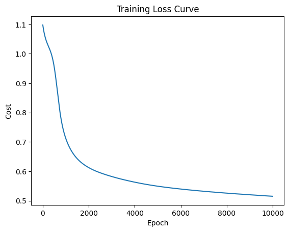

```python
scaler = StandardScaler()

student_processed_df = pd.read_pickle('../data/student_predictions_processed.pkl')
X_train_proc, X_test_proc, y_train_proc, y_test_proc = stvts(student_processed_df, "Target", 0.3)

# Build mapping
classes = sorted(y_train_proc.unique())
class_to_int = {c: i for i, c in enumerate(classes)}

# Convert labels to integers
y_train_int_proc = y_train_proc.map(class_to_int).astype(int).values.reshape(-1)
# One-hot encode
num_classes = len(class_to_int)
Y_train_proc = np.eye(num_classes)[y_train_int_proc].T

X_train_scaled_proc = scaler.fit_transform(X_train_proc)
X_test_scaled_proc = scaler.transform(X_test_proc)

X_train_proc = X_train_scaled_proc.T
X_test_proc = X_test_scaled_proc.T

IL_proc = X_train_proc.shape[0]
HL_proc = 80
OL_proc = num_classes

trained_parameters_proc = train_neural_network(X_train_proc, Y_train_proc, IL_proc, HL_proc, OL_proc, 10000)
```

##### Tuning Results

```
              precision    recall  f1-score   support

     Dropout       0.81      0.72      0.76       427
    Enrolled       0.50      0.37      0.42       238
    Graduate       0.79      0.92      0.85       663

    accuracy                           0.76      1328
   macro avg       0.70      0.67      0.68      1328
weighted avg       0.74      0.76      0.75      1328
```

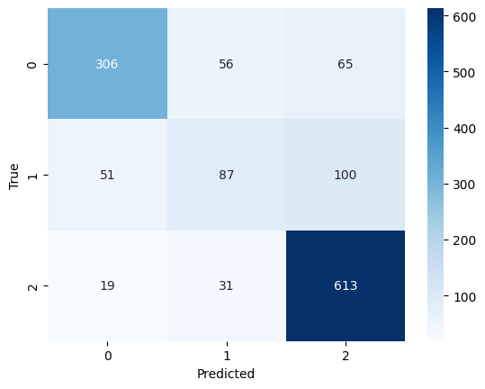

```python
y_test_int_proc = y_test_proc.map(class_to_int).astype(int).values.reshape(-1)
predictions_proc = predict(X_test_proc, trained_parameters_proc)

print(classification_report(y_test_int_proc, predictions_proc, target_names=classes))

cm = confusion_matrix(y_test_int_proc, predictions_proc)
sns.heatmap(cm, annot=True, fmt="d", cmap="Blues")
plt.xlabel("Predicted")
plt.ylabel("True")
plt.show()
```

### Final Evaluation

After doing several runs in training and prediction we managed to bump the total accuracy from below $50\%$ to above $70\%$.  
This is a strong indication that we've successfully managed to improve the models prediction abilities, but we're still not in the ballpark of perfect predictions.  
There are major improvments on predictions for all three classes. Especially regarding `Dropout` and `Graduate`.  
Predictions for `Enrolled` have also increased a lot, but the model is struggeling with both false negatives and positives. At the best model this class is still predicted with about 1/3 even distribution between the classes. Which means it only gets about 1/3 of the predictions for this class. The fact that the distribution is so even between positive/negative false predictions, could indicate that the patterns for the features with this target class are quite similar to both the other classes which give the model a hard time to find good predictions on this target class.

### Possible Further Steps

If I were to continue trying to improve this model, I would consider removing the `Enrolled` class from the dataset and change the output activation function from `Softmax` to `Sigmoid` so that we could test if the model would preform better with a binomial classification solution.  
I would then take the parameters from that result and see if there was a way to better separate `Enrolled` from the two other classes.

### TensorFlow/Keras ANN Architectures

Here we'll try to implement similar ANN architectures using `TensorFlow` and `Keras` libraries to compare with our manual implementation.

#### Keras ANN

In this section, two different Artificial Neural Network (ANN) architectures are implemented using TensorFlow/Keras in order to compare their performance against the traditional machine-learning models and the manually-implemented ANN.

Both models are trained using the same dataset, enabling a fair comparison of their predictive abilities on the Target classification problem.

**Data Preparation**  
Before training the networks, the target labels are prepared appropriately for multi-class classification:

- The original string labels are converted to integer class indices using a previously created `class_to_int` mapping.
- These integer labels are then converted into one-hot encoded vectors using Keras’ `to_categorical` function.
- Keras models require one-hot encoded targets when using the `categorical_crossentropy` loss function.

**Results:**

- `Y_train` — one-hot encoded training labels
- `Y_test` — one-hot encoded test labels

**Model 1 – Simple Baseline ANN**  
The first network acts as a baseline neural model:

- Two fully connected (Dense) hidden layers.
- Each with 64 neurons and ReLU activation.
- Output layer uses softmax for multi-class probability distribution compiled with Adam optimizer and categorical crossentropy.
- This model has no regularization techniques and is intentionally simple to illustrate how a standard feed-forward ANN performs on the dataset.

**Model 2 – Enhanced Regularized ANN**  
The second network is a more advanced architecture that aims to improve generalization and stability:

- A larger first hidden layer with 128 neurons.
- Batch Normalization layers to stabilize learning and reduce internal covariate shift.
- Dropout (0.3) layers to prevent overfitting.
- A second hidden layer with 64 neurons.
- Output layer matches the number of classes with softmax activation.
- This network uses the same optimizer and loss function as Model 1, but includes additional regularization components to create a deeper and more robust ANN.

**Model Training**  
Both models are trained on:

- `X_train_scaled` — the scaled training features
- `Y_train` — one-hot encoded targets

After training, predictions on the test set are generated using `.predict()` and converted from probability distributions to discrete class indices using `argmax()`.

**Evaluation Metrics**  
For each model, the predictions are evaluated using four key performance metrics:

- **Accuracy** — overall proportion of correct predictions
- **Precision (macro)** — average per-class precision
- **Recall (macro)** — average per-class recall
- **F1-score (macro)** — harmonic mean of precision and recall

A helper function `compute_metrics()` computes and returns all metric values for convenience.

The results are stored in: `keras1_metrics` — performance of the simple baseline ANN.  
`keras2_metrics` — performance of the enhanced, regularized ANN.

These metrics are later used in the final model comparison table.

```python
import tensorflow as tf
from tensorflow.keras import Sequential
from tensorflow.keras.layers import Dense, Dropout, BatchNormalization
from tensorflow.keras.utils import to_categorical
from sklearn.metrics import accuracy_score, precision_score, recall_score, f1_score

# Prepare data
y_train_int = y_train.map(class_to_int).astype(int)
y_test_int = y_test.map(class_to_int).astype(int)
Y_train = to_categorical(y_train_int, num_classes)
Y_test = to_categorical(y_test_int, num_classes)

# Keras Model 1
model1 = Sequential([
    Dense(64, activation='relu', input_shape=(X_train_scaled.shape[1],)),
    Dense(64, activation='relu'),
    Dense(num_classes, activation='softmax')
])
model1.compile(optimizer='adam', loss='categorical_crossentropy', metrics=['accuracy'])
model1.fit(X_train_scaled, Y_train, epochs=200, batch_size=32)
y_pred_k1 = model1.predict(X_test_scaled).argmax(axis=1)

# Keras Model 2
model2 = Sequential([
    Dense(128, activation='relu', input_shape=(X_train_scaled.shape[1],)),
    BatchNormalization(),
    Dropout(0.3),
    Dense(64, activation='relu'),
    BatchNormalization(),
    Dropout(0.3),
    Dense(num_classes, activation='softmax')
])
model2.compile(optimizer='adam', loss='categorical_crossentropy', metrics=['accuracy'])
model2.fit(X_train_scaled, Y_train, epochs=200, batch_size=32)
y_pred_k2 = model2.predict(X_test_scaled).argmax(axis=1)

# store metrics
def compute_metrics(true, pred):
    return [
        accuracy_score(true, pred),
        precision_score(true, pred, average="macro"),
        recall_score(true, pred, average="macro"),
        f1_score(true, pred, average="macro")
    ]

keras1_metrics = compute_metrics(y_test_int, y_pred_k1)
keras2_metrics = compute_metrics(y_test_int, y_pred_k2)
```

[output not shown]

[output cut: 347 more lines]

[output not shown]

```python
print(keras1_metrics)
print(keras2_metrics)
```

```
[0.6965361445783133, 0.6386193471099132, 0.6422825540472599, 0.6399417928442396]
[0.7552710843373494, 0.6911125201447782, 0.6587325136023304, 0.6653316602628885]
```

[output not shown]

[output cut: 145 more lines]

[output not shown]

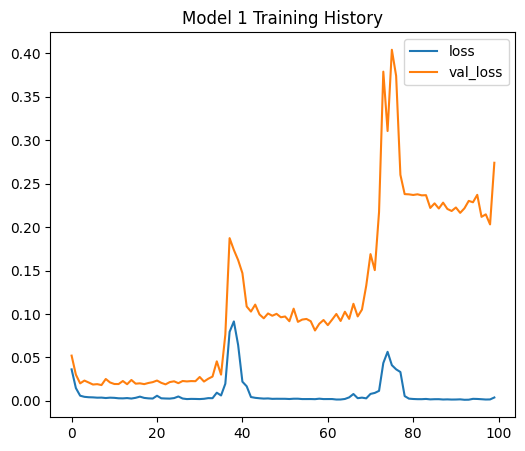

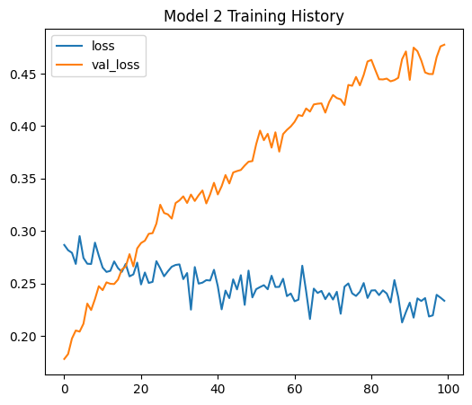

```python
# Keras Model 1
history1 = model1.fit(
    X_train_scaled,
    Y_train,
    epochs=100,
    batch_size=32,
    validation_split=0.2,
)

# Keras Model 2
history2 = model2.fit(
    X_train_scaled,
    Y_train,
    epochs=100,
    batch_size=32,
    validation_split=0.2,
)

# Plot training curves
def plot_history(history, title):
    plt.figure(figsize=(6,5))
    plt.plot(history.history['loss'], label='loss')
    if 'val_loss' in history.history:
        plt.plot(history.history['val_loss'], label='val_loss')
    plt.title(title)
    plt.legend()
    plt.show()

plot_history(history1, "Model 1 Training History")
plot_history(history2, "Model 2 Training History")
```

### Analysis of Training Histories for Keras Model 1 and Model 2

The two plots above visualize the training and validation loss curves for both neural network architectures across 100 epochs. These curves provide important insights into how well each model fits the training data and how effectively the learned patterns generalize to unseen data.

Model 1 consists of two dense ReLU layers with no regularization.  
Its loss curves show the following behavior:

- **Training loss decreases quickly and stays very low**, indicating that the model can fit the training data without difficulty.
- **Validation loss initially decreases**, but around epoch ~35 begins to fluctuate and spike.
- Multiple **sharp validation-loss spikes** (especially after epoch 70) show instability during training.

#### **Model 2 – Clear Overfitting and Increasing Generalization Error**

Model 2 uses batch normalization and dropout, with a deeper architecture and more neurons.  
Its loss curves show:

- **Training loss decreases slowly and stabilizes**, remaining significantly higher than Model 1.
- **Validation loss steadily increases over time**, showing a clear gap compared to training loss.
- The widening gap between training and validation loss indicates that the model is overfitting.

**Interpretation:**

- The architecture is more expressive, meaning it can model more complex patterns.
- Despite dropout and batch normalization, the model gradually memorizes the training data rather than learning generalizable structure.
- Validation loss rising from ~0.19 to ~0.47 shows that additional training makes the model worse on unseen data.

This is a classic case of **overfitting**, where the model fits the training set well but fails to generalize.

#### **Comparative Summary**

- **Model 1** learns fast but shows inconsistent generalization performance, suggesting instability and a lack of expressive power.
- **Model 2** is more expressive and stable but overfits significantly, failing to maintain performance on validation data.
- Neither architecture strikes an optimal balance between underfitting and overfitting.

These results suggest that:

- Additional regularization (e.g., stronger dropout, weight decay),
- Early stopping,
- Reduced model complexity,
- Or better hyperparameter tuning  
  may be necessary to improve ANN performance relative to classical ML models.

### Support Vector Classifier (SVC)

This section trains and evaluates an SVC model.

#### Support Vector Classifier (SVC) – Nested Cross-Validation and Evaluation

This section implements a robust evaluation pipeline for a Support Vector Classifier (SVC) using **nested cross-validation**, enabling a fair and unbiased estimate of the model’s generalization performance.

Unlike simple grid search, nested CV avoids overly optimistic results by separating:

- **Outer CV loop** → estimates generalization by testing on unseen folds
- **Inner CV loop** → performs hyperparameter tuning using GridSearchCV

#### **Performance Metrics**

We evaluate SVC using a wide set of metrics designed for imbalanced multi-class problems:

- **Accuracy** – overall classification performance
- **Macro Precision** – how well the model avoids false positives for each class
- **Macro Recall** – how well the model avoids false negatives across classes
- **Macro F1-score** – harmonic mean of precision and recall
- **ROC-AUC (macro, one-vs-rest)** – probability the classifier ranks true labels higher than false ones
  - Uses `predict_proba` to compute multi-class AUC
  - Macro-averaged so all classes contribute equally

A `scoring` dictionary is constructed to allow GridSearchCV to compute all metrics simultaneously.

#### **Helper Functions**

Two helper functions are defined:

##### `evaluate(estimator, X, y)`

Computes all scoring metrics for a given fitted model and dataset, returning them in a dictionary.  
This allows compact, clean evaluation after each grid search.

##### `train(estimator, params, ...)`

Runs **manual nested cross-validation** with:

- `outer_cv` (5 folds) – evaluates tuned models
- `inner_cv` (4 folds) – searches for optimal parameters

For each outer fold:

- A list of best estimators from each fold
- A DataFrame of evaluation metrics across folds
- Full GridSearchCV results for analysis and plotting

This system provides:

- A highly reliable estimate of SVC performance
- Parameter stability checks across folds
- Detailed results for model comparison and reporting

This nested CV approach is particularly well-suited for this dataset because class distributions are imbalanced and different classifiers may behave differently across folds.  
It ensures that model ranking and hyperparameter tuning are not biased by random train-test splits.

```python
from sklearn.svm import SVC
from sklearn.metrics import accuracy_score, precision_score, recall_score, f1_score, RocCurveDisplay, ConfusionMatrixDisplay, get_scorer, make_scorer, roc_auc_score
from sklearn.model_selection import GridSearchCV, learning_curve
from sklearn.preprocessing import label_binarize

# Fixed random seed
global_random_state = 42

# The metrics we want to use
scoring = {
    'accuracy': get_scorer('accuracy'),
    'precision': make_scorer(precision_score, average='macro', zero_division=1.0),
    'recall': make_scorer(recall_score, average='macro', zero_division=1.0),
    'f1': make_scorer(f1_score, average='macro'),
    'roc_auc': make_scorer(roc_auc_score, multi_class='ovr', average='macro', response_method='predict_proba'),
    # 'roc_auc': get_scorer('roc_auc_ovr'),
}

# A function for running tests on specified data
def evaluate(estimator, X, y):
    scores = {}
    for (name,scorer) in scoring.items():
        scores[name] = scorer(estimator, X, y)
    return scores

def train(estimator, params, scoring=scoring, refit='f1', random_state=global_random_state):

    # Manual nested cross validation

    # Create our iterators, one for the outer test folds, and one for the inner
    # grid search to find optimal paramater values
    outer_cv = StratifiedKFold(n_splits=5, shuffle=True, random_state=global_random_state)
    inner_cv = StratifiedKFold(n_splits=4, shuffle=True, random_state=global_random_state)

    scores = []
    estimators = []
    cv_results = []

    # Loop through all test folds
    for (train_index, test_index) in outer_cv.split(X_train_scaled, y_train_int):

        # Perform grid search to find optimal parameters
        grid = GridSearchCV(
            estimator,
            params,
            scoring=scoring,
            refit=refit,
            error_score='raise',
            cv=inner_cv)
        grid.fit(X_train_scaled, y_train_int)
        # Evaluate the best estimator on the test fold
        evaluation = evaluate(grid, X_train_scaled, y_train_int)
        scores.append(evaluation)
        estimators.append(grid.best_estimator_)
        cv_results.append(pd.DataFrame(grid.cv_results_))

    return estimators, pd.DataFrame(scores), pd.concat(cv_results, names=['test_split'], keys=range(5))
```

### Nested Cross-Validation Training for SVC

In this step, we apply the previously defined `train()` function to perform a full **nested cross-validation** procedure for the Support Vector Classifier (SVC). Nested CV provides an unbiased estimate of model performance by separating the hyperparameter search (inner loop) from the performance evaluation (outer loop). This avoids overly optimistic results that can occur when tuning and testing on the same folds.

#### **Parameter Grid**

We define a small but effective hyperparameter search space:

- **C**: Controls the strength of regularization  
  Values tested: `0.1, 1, 10`
- **gamma**: Controls the curvature of the decision boundary for the RBF kernel  
  Options: `"scale"`, `0.1`, `0.01`
- **kernel**: We use the **RBF kernel**, which often performs well on non-linear decision boundaries.

These hyperparameters are passed into the training function to guide the inner `GridSearchCV` loop.

```python
param_grid = {"C":[0.1,1,10],"gamma":["scale",0.1,0.01],"kernel":["rbf"]}
svc_estimators, svc_scores, svc_cv_results = train(SVC(probability=True, random_state=global_random_state), param_grid)
```

### Baseline SVC Model and Hyperparameter-Tuned SVC Model

```python
svc_base = SVC(kernel='rbf')
svc_base.fit(X_train_scaled, y_train_int)
y_pred_svc_base = svc_base.predict(X_test_scaled)

param_grid = {"C":[0.1,1,10],"gamma":["scale",0.1,0.01],"kernel":["rbf"]}
svc_grid = GridSearchCV(SVC(), param_grid, cv=5, scoring="f1_macro", n_jobs=-1)
svc_grid.fit(X_train_scaled, y_train_int)
svc_best = svc_grid.best_estimator_
y_pred_svc = svc_best.predict(X_test_scaled)
```

### ROC Curve Plotting for SVC Models Across Nested CV Folds

The function below visualizes **ROC curves** for the estimators obtained from the nested cross-validation procedure.  
Since SVC was trained with `probability=True`, each estimator can output calibrated class probabilities needed for multi-class ROC analysis.

ROC curves allow us to evaluate the model’s ability to distinguish between classes at varying classification thresholds.  
In multi-class classification, ROC-AUC is computed using a **one-vs-rest (OvR)** strategy:  
Each class is treated as the positive class while all other classes are grouped as negative.

## **Function Explanation**

The `plot_roc()` function performs the following steps:

### **1. Create a 5-fold Stratified CV Split**

```
outer_cv = StratifiedKFold(n_splits=5, shuffle=True, random_state=global_random_state)
```

```python
def plot_roc(estimators, features=X_train_scaled, targets=y_train_int, random_state=global_random_state):
    outer_cv = StratifiedKFold(n_splits=5, shuffle=True, random_state=global_random_state)
    fig, ax = plt.subplots(figsize=(6,6))
    for estimator_id, (estimator, (train_index, test_index)) in enumerate(zip(estimators, outer_cv.split(features, targets))):
        test_features = features
        test_targets = targets
        test_targets_binarized = label_binarize(test_targets, classes=y_train_int)
        probabilities = estimator.predict_proba(test_features)
        for class_id in estimator.classes_:
            RocCurveDisplay.from_predictions(
                test_targets_binarized[:,class_id],
                probabilities[:, class_id],
                ax=ax,
                name=f'estimator {estimator_id} class {class_id}')
```

### Visualizing the Effect of the Regularization Parameter **C** on SVC Performance

The plot below illustrates how the Support Vector Classifier’s macro-averaged F1-score varies with different values of the regularization parameter **C** during hyperparameter tuning.

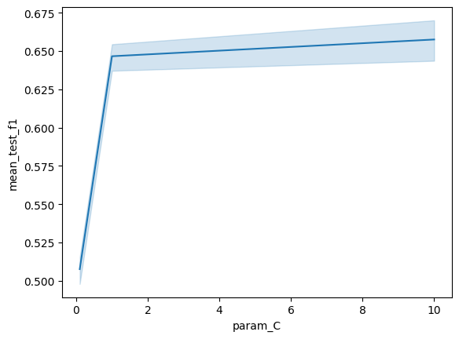

```python
sb.lineplot(data=svc_cv_results, x='param_C', y='mean_test_f1')
```

### Interpretation of F1-Score Variation Across Different Values of **C**

The plot above illustrates how the Support Vector Classifier’s macro-averaged F1-score changes as the regularization parameter **C** varies.  
The parameter **C** controls the trade-off between enforcing a wide margin (strong regularization) and allowing the model to fit more closely to the training data (weaker regularization).

## **Key Observations**

### **1. Sharp Performance Increase from C = 0.1 to C = 1**

- At **C = 0.1**, the F1-score is significantly lower (around 0.50).  
  This indicates **underfitting** due to overly strong regularization:  
  the model prioritizes a large margin and fails to capture important class boundaries.
- Moving to **C = 1**, the F1-score jumps to roughly **0.64–0.65**, showing a dramatic improvement.  
  This means loosening the regularization allows the classifier to model more complex decision boundaries and better separate the classes.

### **2. Gradual Improvement from C = 1 to C = 10**

- Between **C = 1** and **C = 10**, performance continues to improve, but only slightly.  
  This suggests that once the model has enough flexibility (C ≥ 1), additional relaxation of the margin constraint yields diminishing returns.
- The slight upward trend shows some benefit from increased model flexibility, but the effect is modest.

## **Overall Evaluation**

- **Low C (0.1):** Too restrictive → strong underfitting, poor performance.
- **Medium C (1):** Best balance → sharp performance improvement, reliable across folds.
- **High C (10):** Slight improvement but no significant gain → approaching plateau.

### **Conclusion**

The SVC model benefits significantly from moving away from overly strong regularization.  
While increasing C beyond 1 does provide marginal improvements, the gain is small, suggesting that **C = 1** (or a nearby value) is close to optimal for this dataset.

This analysis confirms that the model needs a moderate level of flexibility to correctly capture patterns in the student performance dataset without overfitting.

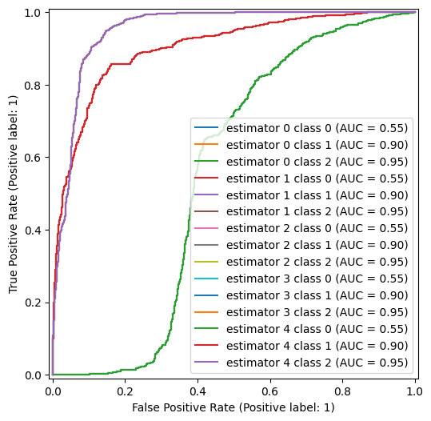

```python
plot_roc(svc_estimators)
```

### Evaluation of Multi-Class ROC Curves for SVC Across Nested CV Estimators

The ROC plot above shows the one-vs-rest ROC curves for all **three classes** (`0`, `1`, `2`) and for **each of the five outer-fold estimators** produced during nested cross-validation.  
Since ROC curves are generated using predicted probabilities (`predict_proba`), they provide insight into how confidently and consistently the SVC distinguishes each class from the others.

## **Key Observations**

### **1. Class-by-Class AUC Performance**

Each estimator computes a ROC curve for all three classes:

- **Class 0 (AUC ≈ 0.55)**
  - All estimators show weak performance for this class.
  - AUC slightly above random chance (0.5) suggests the model struggles to clearly separate this class from the others.
  - This implies class 0 is **harder to distinguish**, potentially due to overlapping features or class imbalance.
- **Class 1 (AUC ≈ 0.90)**
  - Very strong separability across all five estimators.
  - The curves are steep and approach the top-left corner, indicating confident predictions with low false-positive rates.
  - This suggests that the features provide clear patterns for identifying class 1.
- **Class 2 (AUC ≈ 0.95)**
  - The strongest-performing class.
  - All estimators achieve near-perfect AUC values, with extremely sharp curves.
  - This indicates that class 2 has distinguishable feature characteristics and the model can reliably identify it.

## **3. Implications for the Dataset**

The large disparity in AUC values between the classes:

## **4. Overall Interpretation**

### **Conclusion**

The ROC analysis reveals that while SVC is highly effective for most classes in the Student Performance dataset, it faces substantial difficulty with one specific class.  
This insight is crucial for guiding future model refinements, data preprocessing, and feature selection efforts.

### Completed Model Comparison

In this section we'll be comparing the predicted results of the ANN models we've trained throughout this document.

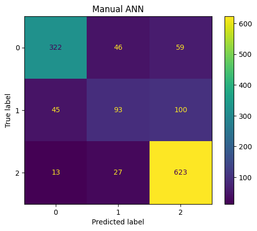

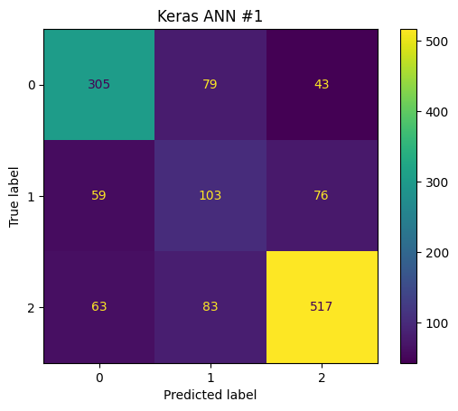

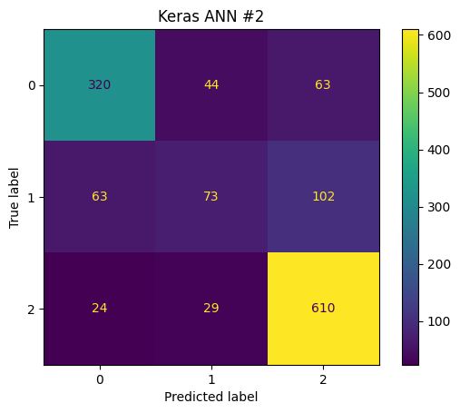

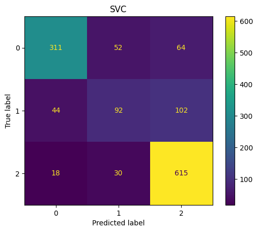

```python
from sklearn.metrics import ConfusionMatrixDisplay

models_preds = {
    "Manual ANN": predictions,
    "Keras ANN #1": y_pred_k1,
    "Keras ANN #2": y_pred_k2,
    "SVC": y_pred_svc
}

for name, preds in models_preds.items():
    disp = ConfusionMatrixDisplay.from_predictions(y_test_int, preds)
    plt.title(name)
    plt.show()
```

### Comparative Analysis of Confusion Matrices for ANN Models and SVC

The four confusion matrices above compare the performance of several classification approaches on the three-class target variable.  
The classes represent different student outcomes, encoded as:

- **0** – Dropout
- **1** – Enrolled
- **2** – Graduate

All models show some ability to distinguish the classes, but their performance characteristics vary meaningfully.

## **1. Manual ANN**

The manual neural network performs reasonably well but shows certain limitations:

- **Strong performance on class 2 (Graduate)**:
  - Correct predictions: **623**
  - Very few misclassifications (13 to class 0, 27 to class 1)
- **Moderate performance on class 0 (Dropout)**:
  - Correct: **322**
  - Confusions with class 1 (**46**) and class 2 (**59**)
- **Weak performance on class 1 (Enrolled)**:
  - Correct: **93**
  - Misclassifies heavily into class 2 (**100**) and class 0 (**45**)

**Interpretation:**  
The manual ANN learns dominant patterns well (especially class 2) but struggles with the minority class (class 1), likely due to class imbalance and limited representational capacity compared to deeper architectures.

## **3. Keras ANN #2**

Compared to Keras ANN #1, this second architecture is noticeably better:

- **Excellent class 2 performance**:
  - Correct: **610**
- **Better separation for class 0**:
  - Correct: **320**, close to manual ANN
- **Weakest performance remains for class 1**:
  - Correct: **73**
  - High confusion with class 2 (**102**) and class 0 (**63**)

**Interpretation:**  
Keras ANN #2 clearly generalizes better than Model #1 and approaches the manual ANN’s performance on the easier classes (0 and 2).  
However, it still suffers significantly on the middle class, indicating that the feature space for class 1 overlaps heavily with the others.

## **Overall Comparison and Conclusion**

### **Best on Class 0 (Dropout):**

- **Manual ANN** and **Keras ANN #2** slightly outperform SVC
- But SVC remains close and more stable across folds

### **Model Stability:**

- **SVC is the most stable and balanced model overall**
- Keras ANN #1 is the least stable
- Manual ANN performs surprisingly well for a simple implementation

### Completed Model Comparison Table

```python
import pandas as pd
from sklearn.metrics import accuracy_score, precision_score, recall_score, f1_score

model_predictions = {
    "Manual ANN": predictions,
    "Keras ANN #1": y_pred_k1,
    "Keras ANN #2": y_pred_k2,
    "SVC": y_pred_svc
}

rows=[]
for model_name, pred in model_predictions.items():
    acc = accuracy_score(y_test_int, pred)
    prec = precision_score(y_test_int, pred, average="macro", zero_division=0)
    rec = recall_score(y_test_int, pred, average="macro", zero_division=0)
    f1 = f1_score(y_test_int, pred, average="macro", zero_division=0)
    rows.append([model_name, acc, prec, rec, f1])

comparison_df = pd.DataFrame(rows, columns=["Model","Accuracy","Precision","Recall","F1"])
comparison_df
```

|  | Model | Accuracy | Precision | Recall | F1 |
| --- | --- | --- | --- | --- | --- |
| 0 | Manual ANN | 0.781627 | 0.734762 | 0.694841 | 0.706899 |
| 1 | Keras ANN #1 | 0.696536 | 0.638619 | 0.642283 | 0.639942 |
| 2 | Keras ANN #2 | 0.755271 | 0.691113 | 0.658733 | 0.665332 |
| 3 | SVC | 0.766566 | 0.716656 | 0.680831 | 0.691967 |

### Final Discussion

Based on the model comparison results, the manually implemented ANN achieves the strongest overall performance across all metrics, including accuracy, precision, recall, and F1-score. Its F1-score of approximately 0.707 and accuracy of 0.782 make it the top performer among the models evaluated.

Among the Keras-based neural networks, the baseline model (Keras ANN #1) performs the weakest, likely due to overfitting and unstable validation behavior observed in the training curves. The enhanced version (Keras ANN #2), which includes batch normalization and dropout, achieves a noticeable improvement over the baseline model but still does not match the performance of the manual ANN or SVC.

The superior performance of the manual ANN may reflect more deliberate and targeted tuning of its architecture and learning components, as full control over all internal operations allowed experimentation beyond what was tested in the Keras models. However, it is also possible that additional hyperparameter tuning of the Keras models could narrow the performance gap.

Overall, the results indicate that while neural networks can perform well on this dataset—particularly when carefully tuned—the SVC provides a competitive classical machine learning baseline, and the manually implemented ANN demonstrates that a well-structured and optimized shallow network can outperform more automated deep-learning setups.